# Bayesian Workflow

Elizabeth King

Kevin Middleton

## This week

1. Bayesian workflow
2. Choosing priors and prior predictive simulation
3. Sampling
4. Diagnostics and posteriors

## Workflow

1. Model specification
2. Prior specification
3. Prior predictive simulation / check
4. Sampling
5. Diagnostics
6. Posterior predictive simulation
7. Summarizing the posterior

## Modeling Tree Size

- Age
- Height

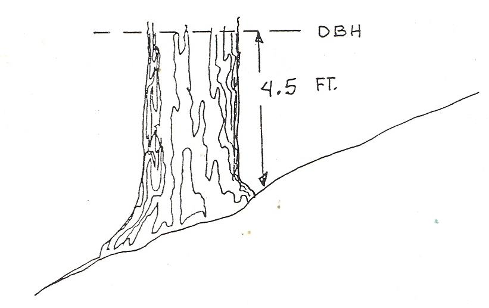

## Model specification

How will we model the relationship between the outcome and predictor(s)?

$$DBH \sim \beta_0$$

$$DBH \sim \beta_0 + \beta_1 age$$

$$\log DBH \sim \beta_0 + \beta_1 \log height$$

## Distribution of the *outcome* variable

How will we model the distribution of the outcome variable?

- Normal (Gaussian): Majority of biological processes
- Log-normal: Many biological processes (few large measures)
- Binomial (Bernoulli): Counts
- Poisson: Counts per time or area
- Exponential: Time-to-event processes

## Relationships between distributions

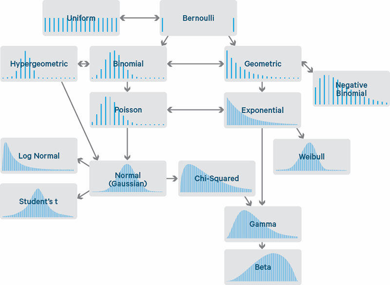

## Choosing distributions

Outcome variable distributions *do not* have to match predictor distributions (priors).

- Outcome variables are usually linear models of predictors
  - Even transformed outcome variables (link functions)
- Predictors are often normally distributed (but they don’t have to be)
  - Many biological processes result in normal distributions

## Model statements

DBH has a normal distribution with some mean ($\mu$) and standard deviation ($\sigma$):

$$DBH \sim Normal(\mu, \sigma)$$

$\mu$ is the sum of $\beta_0$ and $\beta_1$ times $age$:

$$\mu = \beta_0 + \beta_1 age$$

or combined:

$$DBH \sim Normal(\beta_0 + \beta_1 age, \sigma)$$

## Prior specification

What are the distributions and ranges of plausible values for the predictors ($\beta_0$, $\beta_1$, and $\sigma$)?

- $\beta_0$: $\geq$ 0 (DBH at age = 0), use domain knowledge
- $\beta_1$: $\geq$ 0 (DBH increases with age), use domain knowledge
- $\sigma$: *must* be $\geq$ 0, probably a small number unless there is a lot of variation in the samples

Later we will test these with prior predictive checks.

## Bayes rule: Get the posterior

$$\textrm{posterior} = \frac{\textrm{prior} \cdot \textrm{likelihood}}{\textrm{normalizing constant}}$$

$$f(\mathbf{\beta}, y) = \frac{f(\mathbf{\beta}) \cdot L(\mathbf{\beta} | y)}{f(y)}$$

$f(y)$ the probability of observing the data across all possible $\beta$, which make the probability sum to 1. [BayesRules! has a good explanation](https://www.bayesrulesbook.com/chapter-2.html#shortcut-2).

## Sampling to avoid intractable math

- Historically, only outcomes with a few distributions were feasible (Gaussian, Binomial, Poisson) for hand-calculations.
  - Conjugate priors
- Beta prior for a Binomial model has a Beta posterior
  - Similar for other distributions in the “binomial family”
- Normal (Gaussian) prior $\rightarrow$ Normal posterior

## Sampling to avoid intractable math

- With “fast computing machines” (Metropolis et al. 1953), we can sample (Monte Carlo) from the posterior directly
  - Metropolis algorithm (Metropolis et al. 1953)
  - Metropolis-Hastings algorithm (Hastings 1970)
  - Gibbs sampling (Geman and Geman 1984)
  - Hamiltonian Monte Carlo (Duane et al. 1987; Neal 1994; Hoffman and Gelman 2014)

## References

Duane, S., A. D. Kennedy, B. J. Pendleton, and D. Roweth. 1987. Hybrid Monte Carlo. *Phys. Lett. B* 195:216–222.

Geman, S., and D. Geman. 1984. [Stochastic Relaxation, Gibbs Distributions, and the Bayesian Restoration of Images](https://doi.org/10.1109/tpami.1984.4767596). *IEEE Trans. Pattern Anal. Mach. Intell.* 6:721–741.

Hastings, W. K. 1970. [Monte Carlo Sampling Methods Using Markov Chains and Their Applications](https://doi.org/10.2307/2334940). *Biometrika* 57:97–109. [Oxford University Press, Biometrika Trust].

Hoffman, M. D., and A. Gelman. 2014. [The No-U-turn Sampler: Adaptively Setting Path Lengths in Hamiltonian Monte Carlo](http://www.jmlr.org/papers/volume15/hoffman14a/hoffman14a.pdf). *J. Mach. Learn. Res.* 15:1593–1623.

Metropolis, N., A. W. Rosenbluth, M. N. Rosenbluth, A. H. Teller, and E. Teller. 1953. [Equation of State Calculations by Fast Computing Machines](https://doi.org/10.1063/1.1699114). *J. Chem. Phys.* 21:1087–1092. American Institute of Physics.

Neal, R. M. 1994. [An Improved Acceptance Procedure for the Hybrid Monte Carlo Algorithm](https://doi.org/10.1006/jcph.1994.1054). *J. Comput. Phys.* 111:194–203.

[figure not shown]